# Analysis Documentation

Alex Brown

October 18, 2018

### Initial Set Up

#### Library Bank

To clean and analyze the `openmrs` database, I used R. With R I was able to read in the data tables by connecting to the `open_mrs` MS Access database by using the `odbcDriverConnect` function from the `RODBC` package. This allows connection to a database essentially using SQL. In theory, you could use this package to analyze your database with SQL queries. R can send the query to your database and then retrieve the information from you query as a data frame. This is convenient and more efficient with a large database, but R will have no problem with the tables in the`openmrs` database. Therefore, we will just use the `sqlFetch` function to retrieve the tables we need for analysis to save some typing. In addition to the `RODBC` package, I will use `ggplot2` for plotting and `dplyr` for manipulation. It’s very possibly I will need other packages from the `Tidyverse` package set, so I will just load the `Tidyverse` package. In addition, I will use the `lubridate` package for manipulating dates, and the `scales` package for manipulating graphs. We can load all of these packages using the `library` function

```r
#====library bank====
suppressMessages(library(tidyverse, warn.conflicts = F, quietly = T))
library(RODBC)
library(lubridate, warn.conflicts = F)
library(scales, warn.conflicts = F)
```

If you would like to actually run the script on your own computer, please change the below directories appropriately and be sure there is forward slashes `/` in your directory.

```r
access_database <- paste0("F:/School/Tippie_Business Analytics/Health Care Analytics", "/openmrs.accdb")
```

#### Read in Tables

The tables I will use for analysis from the `openmrs` database are: `mrs_concept`, `mrs_encounter`, `mrs_encounter_type`, `mrs_obs`, `mrs_patient`, `mrs_patient_program`, `mrs_program`, and `mrs_tribe`. The process for reading in the tables is the same. I picked only the needed columns and filter out any obvious mistakes. For example, in the `mrs_patient` table, `patient_id` 1 has no information and is not found in any other table we are using. I can `filter` this entry out by removing any observation with a blank `birthdate`. In addition, the `mrs_patient_program` table has the column `voided` which appeared to mean the patient was removed from the program or a mistake was made in the entry. I will show my code for loading the tables in the `Rmarkdown` file so the columns selected can be seen.

*Please Note: to run this on your own computer, you will need to change the directory as noted above.*

```r
#connect to `openmrs` database:
openmrs <- odbcDriverConnect(paste0("Driver={Microsoft Access Driver (*.mdb, *.accdb)};DBQ=",
                                    access_database))
```

### Outlier Analysis

#### The Encounter Table

To investigate the `mrs_encounter` table, I will first join the `mrs_encounter_type` table so the analysis will be more comprehensible. From there, I will make a bar chart to review the break down of different encounter types.

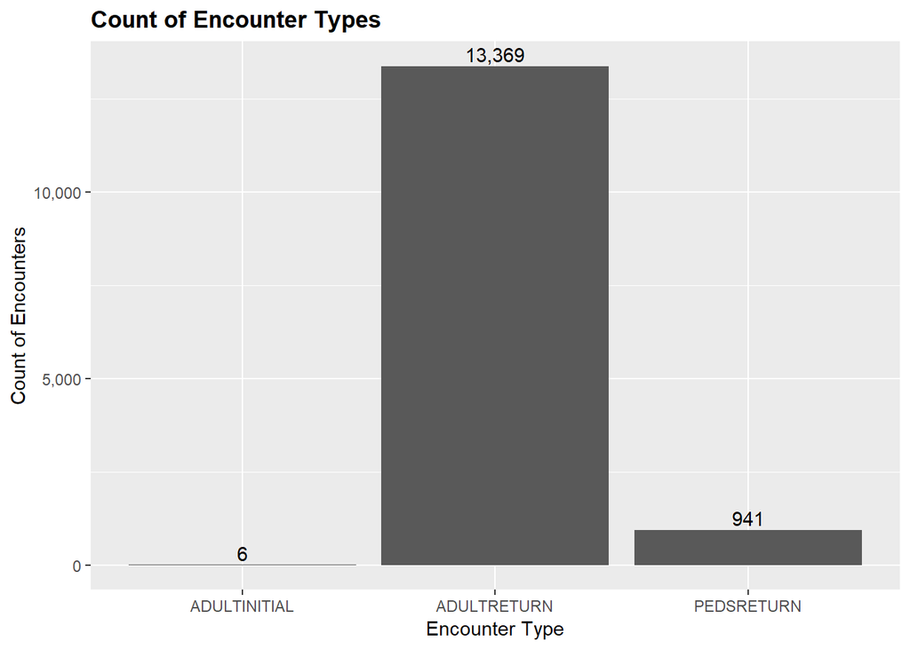

We can see that there are not many `ADULTINITIAL` or `PEDSRETURN` observations. To focus the data set, I will set these types of encounters to be an outlier. To further prove these are outliers, I have created a table which counts the number of of `patient_id` and `encounter_type` occurrences called `count_patient_return`.

```
##   patient_id encounter_type_name n
## 1         39        ADULTINITIAL 3
## 2       3952        ADULTINITIAL 1
## 3       5587        ADULTINITIAL 1
## 4       7107        ADULTINITIAL 1
```

We can see from the above table that we were right in flagging `ADULTINITIAL`. Half of the `ADULTINITIAL` observations are duplicates anyway. In addition, the `PEDSRETURN` observations are so small that, it is unlikely any conclusions can be drawn from them. In addition further analysis I applied, but will now not need to show now that I have flagged the `PEDS`, is that a portion of the observations considered `PEDS` were actually older than 18.

With the data set `count_patient_return` created above, we can also see a break down of how many encounters were made with each patient. I fill filter out anything that is not `ADULTRETURN` for a better representation. In addition, I have created a table for the actual numbers.

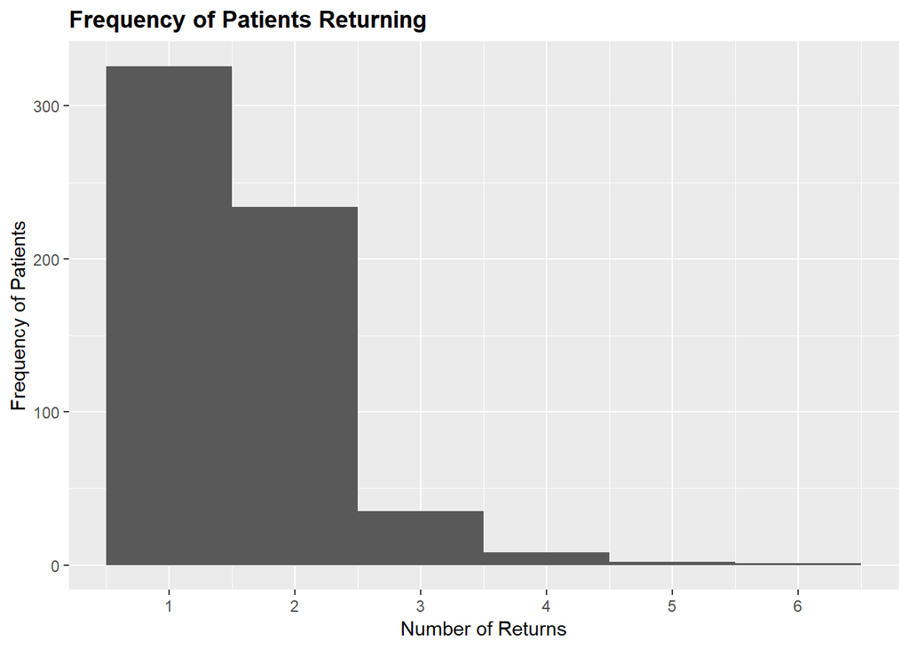

```
##   number_of_returns freq_patients_returning
## 1                 1                     326
## 2                 2                     234
## 3                 3                      35
## 4                 4                       8
## 5                 5                       2
## 6                 6                       1
```

We can see There is very few patients who returned more than once or twice, but we will not note them as an outlier yet.